# Self-Driving Car Engineer Nanodegree

## Project: Build a Traffic Sign Recognition Classifier

In this notebook, a template is provided for you to implement your functionality in stages, which is required to successfully complete this project. If additional code is required that cannot be included in the notebook, be sure that the Python code is successfully imported and included in your submission if necessary.

In addition to implementing code, there is a writeup to complete. The writeup should be completed in a separate file, which can be either a markdown file or a pdf document. There is a [write up template](https://github.com/udacity/CarND-Traffic-Sign-Classifier-Project/blob/master/writeup_template.md) that can be used to guide the writing process. Completing the code template and writeup template will cover all of the [rubric points](https://review.udacity.com/#!/rubrics/481/view) for this project.

The [rubric](https://review.udacity.com/#!/rubrics/481/view) contains "Stand Out Suggestions" for enhancing the project beyond the minimum requirements. The stand out suggestions are optional. If you decide to pursue the "stand out suggestions", you can include the code in this Ipython notebook and also discuss the results in the writeup file.

> **Note:** Code and Markdown cells can be executed using the **Shift + Enter** keyboard shortcut. In addition, Markdown cells can be edited by typically double-clicking the cell to enter edit mode.

## Step 0: Load The Data

```python
# Load pickled data
import pickle
import numpy as np

training_file = 'train.p'
validation_file= 'valid.p'
testing_file = 'test.p'

with open(training_file, mode='rb') as f:
    train = pickle.load(f)
with open(validation_file, mode='rb') as f:
    valid = pickle.load(f)
with open(testing_file, mode='rb') as f:
    test = pickle.load(f)

X_train, y_train = train['features'], train['labels']
X_valid, y_valid = valid['features'], valid['labels']
X_test, y_test = test['features'], test['labels']

assert(len(X_train) == len(y_train))
assert(len(X_valid) == len(y_valid))
assert(len(X_test) == len(y_test))
```

```python
import csv

def read_names(filename):
    with open(filename, 'r') as names:
        return dict(((int(a), b) for a, b in csv.reader(names) if a.isdigit()))

names_file = 'signnames.csv'
sign_names = read_names(names_file)
```

## Step 1: Dataset Summary & Exploration

The pickled data is a dictionary with 4 key/value pairs:

- `'features'` is a 4D array containing raw pixel data of the traffic sign images, (num examples, width, height, channels).
- `'labels'` is a 1D array containing the label/class id of the traffic sign. The file `signnames.csv` contains id -> name mappings for each id.
- `'sizes'` is a list containing tuples, (width, height) representing the original width and height the image.
- `'coords'` is a list containing tuples, (x1, y1, x2, y2) representing coordinates of a bounding box around the sign in the image. **THESE COORDINATES ASSUME THE ORIGINAL IMAGE. THE PICKLED DATA CONTAINS RESIZED VERSIONS (32 by 32) OF THESE IMAGES**

Complete the basic data summary below. Use python, numpy and/or pandas methods to calculate the data summary rather than hard coding the results. For example, the [pandas shape method](http://pandas.pydata.org/pandas-docs/stable/generated/pandas.DataFrame.shape.html) might be useful for calculating some of the summary results.

### Provide a Basic Summary of the Data Set Using Python, Numpy and/or Pandas

```python
import numpy as np

# Number of training examples
n_train = len(y_train)

# Number of validation examples
n_validation = len(y_valid)

# Number of testing examples.
n_test = len(y_test)

# What's the shape of an traffic sign image?
image_shape = X_train.shape[1:]

# How many unique classes/labels there are in the dataset.
n_classes = len(np.unique(np.concatenate((y_train, y_valid, y_test))))

print('Number of training examples =', n_train)
print('Number of validation examples =', n_validation)
print('Number of testing examples =', n_test)
print('Image data shape =', image_shape)
print('Number of classes =', n_classes)
```

```
Number of training examples = 34799
Number of validation examples = 4410
Number of testing examples = 12630
Image data shape = (32, 32, 3)
Number of classes = 43
```

```python
from sklearn.utils import shuffle

X_train, y_train = shuffle(X_train, y_train)
```

### Include an exploratory visualization of the dataset

Visualize the German Traffic Signs Dataset using the pickled file(s). This is open ended, suggestions include: plotting traffic sign images, plotting the count of each sign, etc.

The [Matplotlib](http://matplotlib.org/) [examples](http://matplotlib.org/examples/index.html) and [gallery](http://matplotlib.org/gallery.html) pages are a great resource for doing visualizations in Python.

**NOTE:** It's recommended you start with something simple first. If you wish to do more, come back to it after you've completed the rest of the sections. It can be interesting to look at the distribution of classes in the training, validation and test set. Is the distribution the same? Are there more examples of some classes than others?

```python
import random
import math
import numpy as np
import matplotlib.colors as clr
import matplotlib.pyplot as plt
import cv2
%matplotlib inline
```

```python
# Create and display grid plot
def plot_grid(array, indecies, cols, image_size=(1,1)):

    def normalize(array, min_value=0.0, max_value=1.0):
        return np.dstack(max_value*(a - np.min(a))/(np.max(a) - np.min(a)) + min_value
                         for a in np.dsplit(array, array.shape[-1]))

    mod = len(indecies) % cols
    rows = int(len(indecies) / cols) + (0 if mod == 0 else 1)
    figsize = tuple(a * b for a, b in zip(image_size, (cols, rows)))

    padding = np.tile(np.zeros(array[0].shape), (1, 0 if mod == 0 else cols - mod, 1))
    images = np.hstack((normalize(array[i].copy())) for i in indecies)
    images = np.hstack((images, padding))
    images = np.vstack(np.hsplit(images, rows))

    plt.figure(figsize=figsize)
    plt.axis('off')
    plt.imshow(images.squeeze(),
               cmap=None if len(images[0].shape) > 2 else 'gray',
               interpolation="nearest")
```

```python
def plot_bar(xs, ys, names, xlabel=None, ylabel=None, title=None):
    plt.figure(figsize=(16, 4))
    width = 0.28
    n_series = len(ys)
    n_categories = len(np.unique(np.concatenate(xs)))
    for i, (x, y) in enumerate(zip(xs, ys)):
        plt.bar(x + (i - int(n_series/2))*width, y, width)

    plt.xticks(np.arange(0, n_categories, 2))
    if title: plt.legend(names)
    if xlabel: plt.xlabel(xlabel)
    if ylabel: plt.ylabel(ylabel)
    plt.grid(True)
    if title: plt.title(title)

def plot_histogram(series, names, xlabel=None, ylabel=None, title=None):
    xs, ys = zip(*[(v, 100*c/np.sum(c))
       for v, c in (
           np.unique(d, return_counts=True) for d in series
       )])
    plot_bar(xs, ys, names, xlabel, ylabel, title)
```

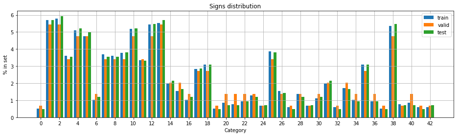

```python
# Labels distribution
plot_histogram((y_train, y_valid, y_test),
               ('train', 'valid', 'test'),
               xlabel='Category', ylabel='% in set', title='Signs distribution')
```

```python
# Take a copy of data just to simplify pre-process editing
X_train_origin, y_train_origin = np.copy(X_train), np.copy(y_train)
X_valid_origin, y_valid_origin = np.copy(X_valid), np.copy(y_valid)
X_test_origin, y_test_origin = np.copy(X_test), np.copy(y_test)
```

[figure not shown]

```python
plot_grid(X_train,
          np.array([np.argwhere(y_train==i)[0:4] for i in range(n_classes)]).flatten(),
          16, image_size=(1, 1))
```

## Step 2: Design and Test a Model Architecture

Design and implement a deep learning model that learns to recognize traffic signs. Train and test your model on the [German Traffic Sign Dataset](http://benchmark.ini.rub.de/?section=gtsrb&subsection=dataset).

The LeNet-5 implementation shown in the classroom at the end of the CNN lesson is a solid starting point. You'll have to change the number of classes and possibly the preprocessing, but aside from that it's plug and play!

With the LeNet-5 solution from the lecture, you should expect a validation set accuracy of about 0.89. To meet specifications, the validation set accuracy will need to be at least 0.93. It is possible to get an even higher accuracy, but 0.93 is the minimum for a successful project submission.

There are various aspects to consider when thinking about this problem:

- Neural network architecture (is the network over or underfitting?)
- Play around preprocessing techniques (normalization, rgb to grayscale, etc)
- Number of examples per label (some have more than others).
- Generate fake data.

Here is an example of a [published baseline model on this problem](http://yann.lecun.com/exdb/publis/pdf/sermanet-ijcnn-11.pdf). It's not required to be familiar with the approach used in the paper but, it's good practice to try to read papers like these.

### Pre-process the Data Set (normalization, grayscale, etc.)

Minimally, the image data should be normalized so that the data has mean zero and equal variance. For image data, `(pixel - 128)/ 128` is a quick way to approximately normalize the data and can be used in this project.

Other pre-processing steps are optional. You can try different techniques to see if it improves performance.

Use the code cell (or multiple code cells, if necessary) to implement the first step of your project.

```python
IMAGE_SIZE=(2.4, 2.4)

def plot_images_in_row(images, title=None, image_size=IMAGE_SIZE, norm=None):
    plt.figure(figsize=(len(images)*image_size[0], image_size[1]))
    if title: plt.suptitle(title)

    for i,img in enumerate(images):
        plt.subplot(1, len(images), i + 1)
        plt.imshow(img.squeeze(),
                   cmap='gray' if len(img.shape) < 3 or img.shape[2] == 1 else None,
                   norm=norm, vmin=0., vmax=255.)

    plt.tight_layout(pad=2)
```

```python
# Image convertion functions
def passthrough(image):
    return image

def grayscale(image):
    return np.expand_dims(cv2.cvtColor(image, cv2.COLOR_RGB2GRAY), -1)
```

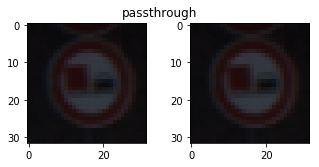

[figure not shown]

```python
for p in (passthrough, grayscale):
    plot_images_in_row((X_train[0], p(X_train[0])), title=p.__name__)
```

```python
# Utilities
def rnd(a, b):
    return (b - a) * random.random() + a

def for_each_depth(method, array):
    return (
        np.expand_dims(method(array), axis=-1) if len(array.shape) < 3 else
        np.stack((method(np.squeeze(a, axis=-1))
                 for a in np.dsplit(array, array.shape[-1])),
                axis=-1))

def for_each_row(method, array):
    r = np.stack((method(np.squeeze(a, axis=0))
                     for a in np.vsplit(array, len(array))),
                    axis=0)
    if len(r.shape) < 4: r = np.expand_dims(r, axis=-1)
    return r
```

```python
# Image transformations
def normalize(array, mean, sigma):
    def normalize_layer(a, mean, sigma):
        if mean is None: mean = np.mean(a)
        if sigma is None: sigma = 1.*(np.max(a) - np.min(a))
        return (a - mean) / sigma
    return for_each_depth(lambda a: normalize_layer(a, mean, sigma), array)

def noise(array, sigma=1.0):
    return array + sigma*np.random.standard_normal(array.shape)

def adjust_contrast(array, factor):
    return for_each_depth(lambda a: a * factor + (1 - factor) * np.mean(a), array)

def adjust_brightness(array, value):
    return for_each_depth(lambda a: a + value * (np.max(a) - np.min(a)), array)

def blur(image, kernel):
    return np.expand_dims(cv2.GaussianBlur(image, kernel, 0), -1)

def rotate(image, angle, scale):
    rows, cols = image.shape[0:2]
    M = cv2.getRotationMatrix2D((cols/2, rows/2), angle, scale)
    return cv2.warpAffine(image, M, (cols, rows))

def shift(image, dx, dy):
    rows, cols = image.shape[0:2]
    M = np.float32([[1, 0, dx], [0, 1, dy]])
    return cv2.warpAffine(image, M, (cols, rows))
```

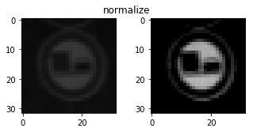

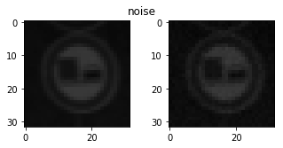

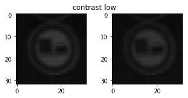

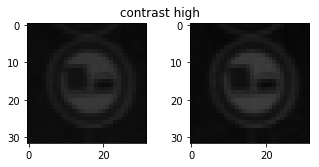

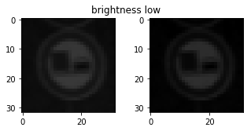

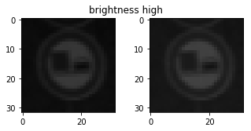

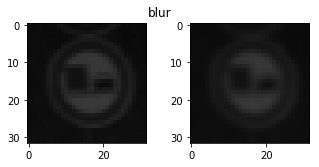

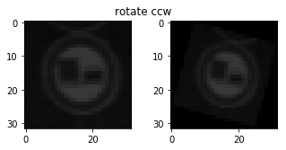

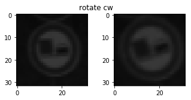

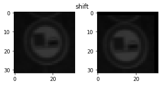

```python
gray = grayscale(X_train[0])
plot_images_in_row((gray, normalize(gray, None, None)), 'normalize', norm=clr.NoNorm())
for p in (
        (lambda i: noise(i, math.sqrt(4)), 'noise'),
        (lambda i: adjust_contrast(i, 0.85), 'contrast low'),
        (lambda i: adjust_contrast(i, 1.15), 'contrast high'),
        (lambda i: adjust_brightness(i, -0.2), 'brightness low'),
        (lambda i: adjust_brightness(i, 0.2), 'brightness high'),
        (lambda i: blur(i, (3, 3)), 'blur'),
        (lambda i: rotate(i, -15, 0.8), 'rotate ccw'),
        (lambda i: rotate(i, 15, 1.2), 'rotate cw'),
        (lambda i: shift(i, -2, 2), 'shift')):
    plot_images_in_row((gray, p[0](gray)), title=p[1], image_size=IMAGE_SIZE)
```

```python
# Batch transformations
def transform_images(array, transformation, *args, **kwargs):
    return for_each_row(lambda i: transformation(i, *args, **kwargs), array)

def boost(collection, labels, transformation, size):
    return (
        np.vstack(transform_images(collection, transformation) for _ in range(size)),
        np.hstack(labels for _ in range(size)))

def equalize(features, labels, transformation, scale=1.0):
    values, count = np.unique(labels, return_counts=True)
    max_count = np.max(count)

    labels_copy = np.copy(labels)
    for v in values:
        indecies, = np.where(labels_copy==v)
        has = len(indecies)
        need = int(scale * max_count) - has

        if has == 0 or need <= 0:
            continue

        transform_indecies = np.random.choice(indecies, need)
        features = np.vstack((features,
                              np.expand_dims(
                                  np.array(list(transformation(features[i])
                                                for i in transform_indecies)), axis=-1)))
        labels = np.hstack((labels, np.full((need,), v)))

    _, count = np.unique(labels, return_counts=True)
    assert(int(scale * np.max(count)) == np.min(count))
    assert(len(features) == len(labels))

    return features, labels
```

```python
# Transformations

NOISE_SIGMA = 3
CONTRAST_ADJUSTMENT = 0.90
EQUALIZATION_FACTOR = 0.33
BOOST_SIZE = 5

def preprocess_transformation(collection, mean=None, sigma=None):
    for processor in (grayscale, lambda i: normalize(i, mean, sigma)):
        collection = transform_images(collection, processor)
    return collection

def boost_transformation(img, mean=None, sigma=None):
    return (
        normalize(
            shift(
                rotate(
                    noise(
                        adjust_brightness(
                            adjust_contrast(
                                passthrough(img
                                ), rnd(0.85, 1.15)
                            ), rnd(-0.1, 0.1)
                        ), math.sqrt(NOISE_SIGMA)
                    ), rnd(-14, 14), rnd(0.8, 1.2)
                ), rnd(-2, 2), rnd(-2, 2)
            ), mean, sigma
        ))

def equalize_tranformation(img):
    return (
        shift(
            rotate(
                adjust_contrast(
                    img, rnd(0.9, 1.1)
                ), rnd(-3, 3), rnd(0.9, 1.1)
            ), rnd(-1, -1), rnd(1, 1)))
```

```python
print("origin:\t", X_train_origin.shape)
X_train, y_train = np.copy(X_train_origin), np.copy(y_train_origin)
print("train:\t", X_train.shape)

X_train = transform_images(X_train, grayscale)
if EQUALIZATION_FACTOR:
    X_train, y_train = equalize(X_train, y_train, equalize_tranformation, EQUALIZATION_FACTOR)

X_boost, y_boost = boost(X_train, y_train, boost_transformation, BOOST_SIZE)
X_train = transform_images(X_train,
                           lambda i:
                               normalize(
                                   noise(
                                       adjust_contrast(
                                           i, CONTRAST_ADJUSTMENT
                                       ), math.sqrt(NOISE_SIGMA)
                                   ), None, None
                               )
                          )
X_train, y_train = np.vstack((X_train, X_boost)), np.hstack((y_train, y_boost))
assert(len(X_train) == len(y_train))
print ("final:\t", X_train.shape)
```

```
origin:	 (34799, 32, 32, 3)
train:	 (34799, 32, 32, 3)
final:	 (257832, 32, 32, 1)
```

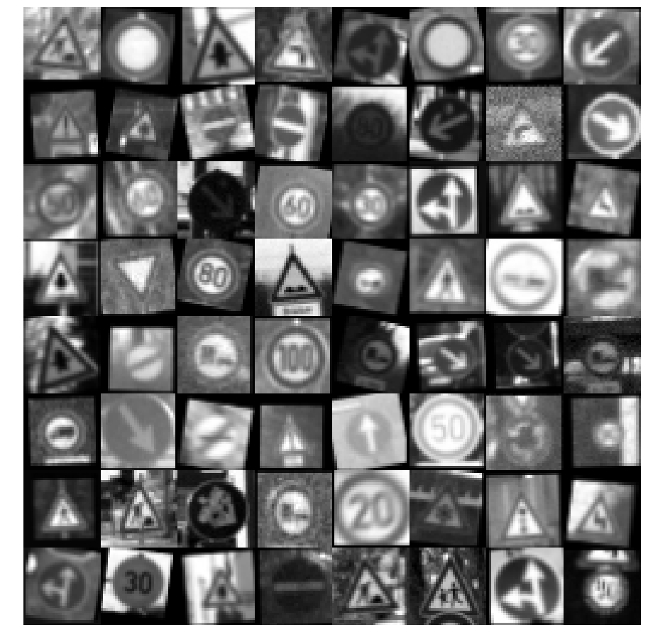

```python
plot_grid(X_train, [random.randint(0, len(X_train)) for _ in range(64)], 8, image_size=(2, 2))
```

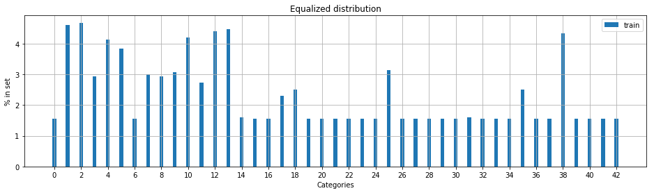

```python
plot_histogram((y_train,), ('train',), xlabel='Categories', ylabel='% in set', title='Equalized distribution')
```

```python
X_valid, y_valid = np.copy(X_valid_origin), np.copy(y_valid_origin)
X_valid = preprocess_transformation(X_valid, None, None)
```

```python
X_test, y_test = np.copy(X_test_origin), np.copy(y_test_origin)
X_test = preprocess_transformation(X_test, None, None)
```

```python
def store(name, features, labels):
    with open(name, 'wb') as output:
        pickle.dump({'features': features, 'labels': labels},
                    output,
                    pickle.HIGHEST_PROTOCOL)

store("train.processed.p", X_train, y_train)
store("valid.processed.p", X_valid, y_valid)
store("test.processed.p", X_test, y_test)
```

```python
n_channels = X_train.shape[-1]
```

# Model Architecture

```python
import tensorflow as tf
```

```python
from tensorflow.contrib.layers import flatten

def LeNet(spec, x, conv_keep_prob, dense_keep_prob, verbose=False):
    # Arguments used for tf.truncated_normal, randomly defines variables for the weights and biases for each layer
    mu = 0
    sigma = 0.1
    m = 3

    def convolution(x, W, b, names, paddings):
        assert(len(names) == len(paddings))
        for name, padding in zip(names, paddings):
            x = tf.nn.conv2d(x, W[name], strides=[1, 1, 1, 1], padding=padding) + b[name]
            if verbose: print("conv", x)
            x = tf.nn.relu(x)
            if verbose: print("relu", x)
        return x

    def pre(x):
        weights = {
            'c7x7_1': tf.Variable(tf.truncated_normal([7, 7, n_channels, 2**(m + 0)], mu, sigma)),
            'c1x1_1': tf.Variable(tf.truncated_normal([1, 1, 2**(m + 0), 2**(m - 1)], mu, sigma)),
            'c5x5_1': tf.Variable(tf.truncated_normal([5, 5, 2**(m - 1), 2**(m + 2)], mu, sigma)),
        }
        biases = {
            'c7x7_1': tf.Variable(tf.zeros(2**(m + 0))),
            'c1x1_1': tf.Variable(tf.zeros(2**(m - 1))),
            'c5x5_1': tf.Variable(tf.zeros(2**(m + 2))),
        }

        # Preprocessing
        x = convolution(x, weights, biases, ('c7x7_1', 'c1x1_1', 'c5x5_1',), ('SAME', 'VALID', 'VALID',))
        x = tf.nn.max_pool(x, ksize=[1, 2, 2, 1], strides=[1, 2, 2, 1], padding='VALID')
        if verbose: print("max-pool", x)
        if verbose: print("pre")
        return x

    def branch_a(x):
        weights = {
            'c1x1_1': tf.Variable(tf.truncated_normal([1, 1, 2**(m + 2), 2**(m + 1)], mu, sigma)),
            'c5x5_1': tf.Variable(tf.truncated_normal([5, 5, 2**(m + 1), 2**(m + 4)], mu, sigma)),
            'c1x1_2': tf.Variable(tf.truncated_normal([1, 1, 2**(m + 4), 2**(m + 3)], mu, sigma)),
            'c3x3_2': tf.Variable(tf.truncated_normal([3, 3, 2**(m + 3), 2**(m + 5)], mu, sigma)),
        }
        biases = {
            'c1x1_1': tf.Variable(tf.zeros(2**(m + 1))),
            'c5x5_1': tf.Variable(tf.zeros(2**(m + 4))),
            'c1x1_2': tf.Variable(tf.zeros(2**(m + 3))),
            'c3x3_2': tf.Variable(tf.zeros(2**(m + 5))),
        }

        x = convolution(x, weights, biases, ('c1x1_1', 'c5x5_1'), ('VALID', 'VALID'))
        x = tf.nn.max_pool(x, ksize=[1, 2, 2, 1], strides=[1, 2, 2, 1], padding='VALID')
        if verbose: print("max-pool", x)

        x = convolution(x, weights, biases, ('c1x1_2', 'c3x3_2'), ('VALID', 'VALID'))
        x = tf.nn.max_pool(x, ksize=[1, 3, 3, 1], strides=[1, 2, 2, 1], padding='VALID')
        if verbose: print("max-pool", x)
        if verbose: print("branch_a")
        return x

    def branch_b(x):
        weights = {
            'c1x1_1': tf.Variable(tf.truncated_normal([1, 1, 2**(m + 2), 2**(m + 1)], mu, sigma)),
            'c3x3_1': tf.Variable(tf.truncated_normal([3, 3, 2**(m + 1), 2**(m + 4)], mu, sigma)),
            'c1x1_2': tf.Variable(tf.truncated_normal([1, 1, 2**(m + 4), 2**(m + 2)], mu, sigma)),
            'c3x3_2': tf.Variable(tf.truncated_normal([3, 3, 2**(m + 2), 2**(m + 4)], mu, sigma)),
            'c1x1_3': tf.Variable(tf.truncated_normal([1, 1, 2**(m + 4), 2**(m + 2)], mu, sigma)),
            'c3x3_3': tf.Variable(tf.truncated_normal([3, 3, 2**(m + 2), 2**(m + 4)], mu, sigma)),

            'c1x1_4': tf.Variable(tf.truncated_normal([1, 1, 2**(m + 4), 2**(m + 3)], mu, sigma)),
            'c5x5_4': tf.Variable(tf.truncated_normal([5, 5, 2**(m + 3), 2**(m + 5)], mu, sigma)),
        }
        biases = {
            'c1x1_1': tf.Variable(tf.zeros(2**(m + 1))),
            'c3x3_1': tf.Variable(tf.zeros(2**(m + 4))),
            'c1x1_2': tf.Variable(tf.zeros(2**(m + 2))),
            'c3x3_2': tf.Variable(tf.zeros(2**(m + 4))),
            'c1x1_3': tf.Variable(tf.zeros(2**(m + 2))),
            'c3x3_3': tf.Variable(tf.zeros(2**(m + 4))),

            'c1x1_4': tf.Variable(tf.zeros(2**(m + 3))),
            'c5x5_4': tf.Variable(tf.zeros(2**(m + 5))),
        }

        x = convolution(x, weights, biases,
                        ('c1x1_1', 'c3x3_1', 'c1x1_2', 'c3x3_2', 'c1x1_3', 'c3x3_3'),
                        ('VALID', 'VALID', 'VALID', 'VALID', 'VALID', 'VALID'))
        x = tf.nn.max_pool(x, ksize=[1, 3, 3, 1], strides=[1, 1, 1, 1], padding='VALID')
        if verbose: print("max-pool", x)

        x = convolution(x, weights, biases, ('c1x1_4', 'c5x5_4'), ('VALID', 'VALID'))
        x = tf.nn.max_pool(x, ksize=[1, 2, 2, 1], strides=[1, 1, 1, 1], padding='VALID')
        if verbose: print("max-pool", x)
        if verbose: print("branch_b")
        return x

    def branch_c(x):
        weights = {
            'c1x1_1': tf.Variable(tf.truncated_normal([1, 1, 2**(m + 2), 2**(m + 1)], mu, sigma)),
            'c7x7_1': tf.Variable(tf.truncated_normal([7, 7, 2**(m + 1), 2**(m + 3)], mu, sigma)),
            'c1x1_2': tf.Variable(tf.truncated_normal([1, 1, 2**(m + 3), 2**(m + 2)], mu, sigma)),
            'c3x3_2': tf.Variable(tf.truncated_normal([3, 3, 2**(m + 2), 2**(m + 5)], mu, sigma)),
        }
        biases = {
            'c1x1_1': tf.Variable(tf.zeros(2**(m + 1))),
            'c7x7_1': tf.Variable(tf.zeros(2**(m + 3))),
            'c1x1_2': tf.Variable(tf.zeros(2**(m + 2))),
            'c3x3_2': tf.Variable(tf.zeros(2**(m + 5))),
        }

        x = convolution(x, weights, biases, ('c1x1_1', 'c7x7_1'), ('VALID', 'VALID'))
        x = tf.nn.max_pool(x, ksize=[1, 2, 2, 1], strides=[1, 2, 2, 1], padding='VALID')
        if verbose: print("max-pool", x)

        x = convolution(x, weights, biases, ('c1x1_2', 'c3x3_2'), ('VALID', 'VALID'))
        x = tf.nn.max_pool(x, ksize=[1, 2, 2, 1], strides=[1, 2, 2, 1], padding='VALID')
        if verbose: print("max-pool", x)
        if verbose: print("branch_c", x)
        return x

    def total_depth(*args):
        return sum(int(x.get_shape()[-1]) for x in args)

    def fc(x, out_shape, add_activation=True):
        W = tf.Variable(tf.truncated_normal([int(x.get_shape()[-1]), out_shape], mu, sigma))
        b = tf.Variable(tf.zeros(int(out_shape)))
        x = tf.nn.xw_plus_b(x, W, b)
        if verbose: print("fc", x)
        x = tf.nn.tanh(x) if add_activation else x
        if verbose: print("tanh" if add_activation else "no-op", x)
        return x

    def fc_full(x): return fc(x, int(x.get_shape()[-1])>>0)
    def fc_half(x): return fc(x, int(x.get_shape()[-1])>>1)
    def fc_quarter(x): return fc(x, int(x.get_shape()[-1])>>2)
    def out(x): return fc(x, n_classes, add_activation=False)

    branches = { 'a': branch_a, 'b': branch_b, 'c': branch_c, }
    denses = { 'f': fc_full, 'h': fc_half, 'q': fc_quarter }

    if verbose: print('input', x)

    x = pre(x)
    x = tf.concat(
        tuple(tf.contrib.layers.flatten(branches[b](tf.identity(x)))
              for b in spec if b in branches),
        axis=1)
    x = tf.nn.dropout(x, conv_keep_prob)
    if verbose: print("dropout", x)

    for d in spec:
        if d in denses:
            x = denses[d](x)
    x = tf.nn.dropout(x, dense_keep_prob)
    if verbose: print("dropout", x)

    return out(x)
```

### Train, Validate and Test the Model

A validation set can be used to assess how well the model is performing. A low accuracy on the training and validation sets imply underfitting. A high accuracy on the training set but low accuracy on the validation set implies overfitting.

```python
# Knobs
EPOCHS = 25
BATCH_SIZE = 1280
RATE = 0.001

conv_keep_probability = 0.25
dense_keep_probability = 0.40

SPEC='abch'
```

```python
def loss_operation(model):
    logits, _, _, _ = model

    y = tf.placeholder(tf.int32, (None))
    one_hot_y = tf.one_hot(y, n_classes)

    cross_entropy = tf.nn.softmax_cross_entropy_with_logits(labels=one_hot_y, logits=logits)
    return tf.reduce_mean(cross_entropy), y
```

```python
def create_model(spec, verbose=False):
    x = tf.placeholder(tf.float32, (None, 32, 32, n_channels))
    conv_keep_prob = tf.placeholder_with_default(1., (None), name='ConvDropout')
    dense_keep_prob = tf.placeholder_with_default(1., (None), name='DenseDropout')

    logits = LeNet(spec, x, conv_keep_prob, dense_keep_prob, verbose=verbose)

    return logits, x, conv_keep_prob, dense_keep_prob
```

```python
def train_operation(model):
    logits, _, _, _ = model

    y = tf.placeholder(tf.int32, (None))
    one_hot_y = tf.one_hot(y, n_classes)

    cross_entropy = tf.nn.softmax_cross_entropy_with_logits(labels=one_hot_y, logits=logits)
    loss_operation = tf.reduce_mean(cross_entropy)
    optimizer = tf.train.AdamOptimizer(learning_rate=RATE)
    return optimizer.minimize(loss_operation), y

def train(operation, model, X_data, y_data, conv_keep_probability, dense_keep_probability):
    training_operation, y = operation
    _, x, conv_keep_prob, dense_keep_prob = model
    for offset in range(0, len(X_data), BATCH_SIZE):
        batch_x, batch_y = X_train[offset:offset+BATCH_SIZE], y_train[offset:offset+BATCH_SIZE]
        sess.run(training_operation,
                 feed_dict={x: batch_x,
                            y: batch_y,
                            conv_keep_prob: conv_keep_probability,
                            dense_keep_prob: dense_keep_probability})
```

```python
def accuracy_operation(model):
    logits, _, _, _ = model
    y = tf.placeholder(tf.int32, (None))
    one_hot_y = tf.one_hot(y, n_classes)

    correct_prediction = tf.equal(tf.argmax(logits, 1), tf.argmax(one_hot_y, 1))
    return tf.reduce_mean(tf.cast(correct_prediction, tf.float32)), y

def evaluate(operation, model, X_data, y_data, conv_keep_probability=1.0, dense_keep_probability=1.0):
    accuracy_operation, y = operation
    _, x, conv_keep_prob, dense_keep_prob = model

    num_examples = len(X_data)
    total_accuracy = 0
    sess = tf.get_default_session()
    for offset in range(0, num_examples, BATCH_SIZE):
        batch_x, batch_y = X_data[offset:offset+BATCH_SIZE], y_data[offset:offset+BATCH_SIZE]
        accuracy = sess.run(accuracy_operation,
                            feed_dict={x: batch_x,
                                       y: batch_y,
                                       conv_keep_prob: conv_keep_probability,
                                       dense_keep_prob: dense_keep_probability})
        total_accuracy += (accuracy*len(batch_x))
    return total_accuracy/num_examples
```

```python
import datetime as dt

tf.reset_default_graph()

model = create_model(SPEC, verbose=False)
train_op = train_operation(model)
accuracy_op = accuracy_operation(model)

saver = tf.train.Saver()

training_curve = np.empty((EPOCHS, 2))
dropout = (conv_keep_probability, dense_keep_probability)

# Training
with tf.Session() as sess:
    sess.run(tf.global_variables_initializer())
    print("Training...", SPEC)
    for i in range(EPOCHS):
        epoch_begin = dt.datetime.now()
        train(train_op, model, *shuffle(X_train, y_train), *dropout)
        epoch_end = dt.datetime.now()

        train_accuracy = evaluate(accuracy_op, model, X_train, y_train, *dropout)
        validation_accuracy = evaluate(accuracy_op, model, X_valid, y_valid)

        print("E{:02} {:.3f}s => "
              "Train Accuracy = {:.3f}; Validation Accuracy = {:.3f}".format(
                  i+1, (epoch_end - epoch_begin).total_seconds(),
                  train_accuracy, validation_accuracy))
        training_curve[i] = (train_accuracy, validation_accuracy)

    test_accuracy = evaluate(accuracy_op, model, X_test, y_test)
    print("Test Accuracy = {:.3f}".format(test_accuracy))

    model_file = saver.save(sess, './lenet-{}-{:.3f}'.format(SPEC, test_accuracy))
    print("Model saved into", model_file)

with open('./curve-{}-{:.3f}.p'.format(SPEC, test_accuracy), 'wb') as curve:
    pickle.dump(training_curve, curve)
```

```
Training... abch
E01 94.966s => Train Accuracy = 0.623; Validation Accuracy = 0.825
E02 95.308s => Train Accuracy = 0.900; Validation Accuracy = 0.978
E03 95.187s => Train Accuracy = 0.948; Validation Accuracy = 0.983
E04 95.172s => Train Accuracy = 0.967; Validation Accuracy = 0.986
E05 94.715s => Train Accuracy = 0.974; Validation Accuracy = 0.987
E06 95.161s => Train Accuracy = 0.978; Validation Accuracy = 0.990
E07 94.503s => Train Accuracy = 0.982; Validation Accuracy = 0.992
E08 95.079s => Train Accuracy = 0.987; Validation Accuracy = 0.989
E09 94.342s => Train Accuracy = 0.987; Validation Accuracy = 0.990
E10 95.100s => Train Accuracy = 0.989; Validation Accuracy = 0.988
E11 94.203s => Train Accuracy = 0.990; Validation Accuracy = 0.992
E12 95.189s => Train Accuracy = 0.989; Validation Accuracy = 0.992
E13 95.093s => Train Accuracy = 0.992; Validation Accuracy = 0.987
E14 95.366s => Train Accuracy = 0.990; Validation Accuracy = 0.989
E15 94.256s => Train Accuracy = 0.994; Validation Accuracy = 0.990
E16 95.084s => Train Accuracy = 0.994; Validation Accuracy = 0.995
E17 95.112s => Train Accuracy = 0.993; Validation Accuracy = 0.991
E18 94.238s => Train Accuracy = 0.995; Validation Accuracy = 0.995
E19 95.539s => Train Accuracy = 0.994; Validation Accuracy = 0.990
E20 94.146s => Train Accuracy = 0.995; Validation Accuracy = 0.995
E21 95.989s => Train Accuracy = 0.995; Validation Accuracy = 0.996
E22 95.289s => Train Accuracy = 0.995; Validation Accuracy = 0.993
E23 94.723s => Train Accuracy = 0.995; Validation Accuracy = 0.993
E24 95.022s => Train Accuracy = 0.993; Validation Accuracy = 0.992
E25 94.838s => Train Accuracy = 0.996; Validation Accuracy = 0.994
Test Accuracy = 0.984
Model saved into ./lenet-abch-0.984
```

```python
MODEL_FILE = './lenet-abch-0.984'
CURVE_FILE = './curve-abch-0.984.p'
```

```python
tf.reset_default_graph()

model = create_model(SPEC)
accuracy_op = accuracy_operation(model)

saver = tf.train.Saver()
with tf.Session() as sess:
    saver.restore(sess, MODEL_FILE)
    print("train -", evaluate(accuracy_op, model, X_train, y_train))
    print("valid -", evaluate(accuracy_op, model, X_valid, y_valid))
    print("test -", evaluate(accuracy_op, model, X_test, y_test))
```

```
INFO:tensorflow:Restoring parameters from ./lenet-abch-0.984
train - 0.998386550776
valid - 0.99387755794
test - 0.983768805142
```

[figure not shown]

```python
with open(CURVE_FILE, 'rb') as f:
    curve = pickle.load(f)

plt.figure(figsize=(12, 4))
plt.plot(range(1, len(curve)+1), curve)
plt.ylabel('accuracy')
plt.xlabel('epoch')
plt.legend(('train', 'valid'))
plt.grid()
plt.xticks(range(1, len(curve)+1))
plt.title('Training curve')
```

```python
def topK_operation(model, k):
    logits, _, _, _ = model
    softmax_prediction = tf.nn.softmax(logits)
    return tf.nn.top_k(softmax_prediction, k)

def topK(op, model, X_data):
    _, x, _, _ = model

    sess = tf.get_default_session()
    return (np.vstack(x)
            for x in zip(*(
                sess.run(op, feed_dict={x: X_data[offset:offset+BATCH_SIZE]})
                for offset in range(0, len(X_data), BATCH_SIZE))))

tf.reset_default_graph()
model = create_model(SPEC)
top5_op = topK_operation(model, 5)

saver = tf.train.Saver()
with tf.Session() as sess:
    saver.restore(sess, MODEL_FILE)
    p_test, pi_test = topK(top5_op, model, X_test)
```

```
INFO:tensorflow:Restoring parameters from ./lenet-abch-0.984
```

```python
def plot_probabilities(image, image_idx, probabilities, probabilities_idx, names):
    plt.figure(figsize=(10, IMAGE_SIZE[0]))

    plt.subplot(121)
    plt.imshow(image, cmap='gray')
    plt.title('{}, {}'.format(image_idx, names[image_idx]))
    plt.subplots_adjust(wspace=0, hspace=0.1)

    plt.subplot(122)
    ticks = range(len(probabilities))
    plt.bar(ticks, probabilities)
    plt.xticks(ticks, ('{}\n{}'.format(i, names[i].replace(' ', '\n')) for i in probabilities_idx))
    plt.title('probabilities')
    plt.subplots_adjust(wspace=0, hspace=0)
```

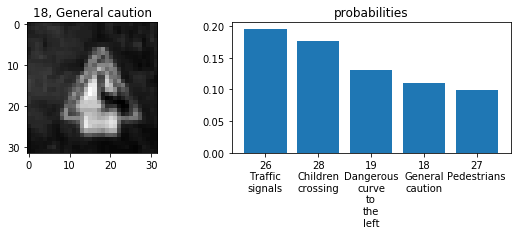

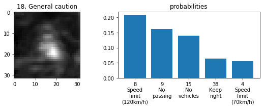

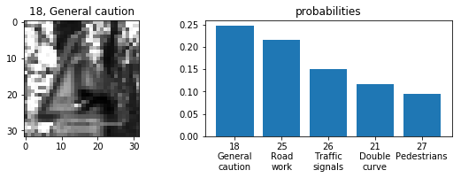

```python
# 3 most confusing (lowest high probability)
num_to_display = 3
for i in p_test[:,0].argsort()[:num_to_display]:
    plot_probabilities(X_test[i].squeeze(), y_test[i], p_test[i], pi_test[i], sign_names)
```

```python
misclassified = np.where(y_test != pi_test[:,0])
y_m = y_test[misclassified]
X_m = X_test[misclassified]
p_m = p_test[misclassified]
pi_m = pi_test[misclassified]
```

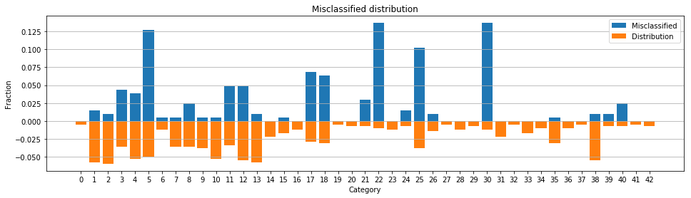

```python
v, c = np.unique(y_m, return_counts=True)

plt.figure(figsize=(16, 4))
plt.xticks(range(n_classes))
plt.bar(v, c/np.sum(c), label='Misclassified')
plt.bar(range(n_classes), -np.unique(y_test, return_counts=True)[1]/len(y_test), label='Distribution')
plt.xlabel('Category')
plt.ylabel('Fraction')
plt.title('Misclassified distribution')
plt.grid(axis='y')
plt.legend()
```